# NPB to select exposures for the BKMR model of adiposity

Sheena Martenies

4/16/2020

This markdown summarizes the NPB analsys trying to reduce the number of predictors for the BKMR model for adiposity.

**Analytical notes:**

- I met with Lauren last fall to discuss how to select priors for the NPB model. She gave me some hints, which were helpful. However, I’m still unsure I selected the correct ones
- Because this is a screening model, I relaxed the PIP criterion for “significance” and included anything with a PIP > 0.40
- Overall, I ended up with 10 exposures with PIPs > 0.4.

Read in the dataset and get the exposures, outcome and covariates

```r
#' Read in the clean dataset
hs_data <- read_csv(here::here("Data", "HS_Clean_Data.csv"))
nrow(hs_data)
```

```
## [1] 1410
```

```r
hs_data2 <- filter(hs_data, include == 1) %>%
  select(
    #' Exposures
         mean_pm, mean_o3, pct_tree_cover, pct_impervious,
         mean_aadt_intensity, dist_m_tri:dist_m_mine_well,
         cvd_rate_adj, res_rate_adj, violent_crime_rate, property_crime_rate,
         pct_less_hs, pct_unemp, pct_limited_eng, pct_hh_pov,

    #' Covariates
         latina_re, black_re, other_re,
         ed_no_hs, ed_hs, ed_aa, ed_4yr,
         low_bmi, ovwt_bmi, obese_bmi,
         maternal_age, any_smoker, smokeSH, mean_cpss, mean_epsd,
         male, gest_age_w, days_to_peapod,

    #' Outcomes
         adiposity) %>%
  na.omit()
```

We have complete outcome, exposure, and covariate data for 55.3% of participants. Note: the adiposity models include days to PEAPOD measurement.

I used Lauren’s `mmpack` package to fit the NPB model.

```r
#' -----------------------------------------------------------------------------
#' Nonparametric Bayesian Shrinkage (NPB): Birth weight
#' -----------------------------------------------------------------------------

# library(devtools)
# install_github("lvhoskovec/mmpack", build_vignettes = TRUE)
# browseVignettes("mmpack")

library(mmpack)

#' Exposure data
X <- select(hs_data2, mean_pm, mean_o3, pct_tree_cover, pct_impervious,
            mean_aadt_intensity, dist_m_tri:dist_m_mine_well,
            cvd_rate_adj, res_rate_adj, violent_crime_rate, property_crime_rate,
            pct_less_hs, pct_unemp, pct_limited_eng, pct_hh_pov) %>%
  as.matrix()
head(X)
```

```
##       mean_pm  mean_o3 pct_tree_cover pct_impervious mean_aadt_intensity
## [1,] 8.483046 47.19072       6.006276       43.30893          10128.4962
## [2,] 6.598608 50.05090       7.281109       48.36432          10749.0359
## [3,] 7.454146 48.57052      17.205991       31.67281           9048.6468
## [4,] 6.671239 50.06429       6.842898       45.00359           4223.3434
## [5,] 7.122537 50.14275       3.357792       28.16745            858.7283
## [6,] 7.637453 47.03125      10.743612       45.87564          15603.9800
##      dist_m_tri dist_m_npl dist_m_waste_site dist_m_major_emit dist_m_cafo
## [1,]   2827.538   729.2371          4829.780          7968.654    29116.58
## [2,]   1576.420  5239.2211          4417.792          3780.951    51044.30
## [3,]   3350.303  2992.2968          5211.871          7423.232    36079.21
## [4,]   3364.954  6998.1286          8921.318          9636.816    42235.78
## [5,]   2923.811  3427.2247          7006.042          6806.912    29145.98
## [6,]   3364.200  3166.5395          4484.960          5265.285    43921.85
##      dist_m_mine_well cvd_rate_adj res_rate_adj violent_crime_rate
## [1,]        1749.1256     275.2480     155.7767          14.377133
## [2,]        7354.5310     279.6435     226.8038           8.905404
## [3,]        4887.2996     221.0414     157.6974           7.636888
## [4,]        3752.6399     203.8812     142.5368           2.850212
## [5,]         729.7784     194.1983     101.0046           5.435988
## [6,]        5870.6867     174.3361     120.3281           5.035971
##      property_crime_rate pct_less_hs pct_unemp pct_limited_eng pct_hh_pov
## [1,]            37.32935   31.784946 11.529628       26.114650  12.010919
## [2,]            67.03932   15.290231  4.908306        8.500401  18.123496
## [3,]            46.78194    6.891702  4.564963        0.000000   6.307978
## [4,]            21.95270    2.725915  5.623583        1.350621   9.292274
## [5,]            22.49834   12.919186  5.234103        6.307385   2.115768
## [6,]            47.15500    3.842365 10.000000        5.121799  25.171768
```

```r
#' Take a look at the covariance in the exposure data
var(X)
```

```
##                             mean_pm        mean_o3 pct_tree_cover
## mean_pm                 0.387935651   -0.006062324    -0.24186797
## mean_o3                -0.006062324    8.955071063    -0.42975173
## pct_tree_cover         -0.241867968   -0.429751728    10.14239201
## pct_impervious          0.374669222   -1.022666581     7.01532904
## mean_aadt_intensity  -244.348900205  303.692966735  9016.25164719
## dist_m_tri           -262.436608185  331.077954338  -208.41963901
## dist_m_npl           -323.917936386  588.917794378   165.47445225
## dist_m_waste_site    -255.868380544  139.101947771  1967.86242644
## dist_m_major_emit      54.696478097  795.943835213   109.80052618
## dist_m_cafo         -1416.446418998 -161.908280851 10579.76974425
## dist_m_mine_well     -346.805134977 -503.738613039  3305.89212551
## cvd_rate_adj            3.764074301    4.075840732   -24.37524733
## res_rate_adj            1.965274289    1.428149656    -1.41491470
## violent_crime_rate      0.155877411    0.749569861    -3.73949960
## property_crime_rate     1.705778861   -1.922286944   -21.72665992
## pct_less_hs             1.150349004    1.853281484    -7.56529205
## pct_unemp               0.055091002    0.506543293    -0.09840703
## pct_limited_eng         0.412512233    1.029344921    -2.79407307
## pct_hh_pov              0.606596961    0.246447334     0.62423227
##                     pct_impervious mean_aadt_intensity    dist_m_tri
## mean_pm                  0.3746692           -244.3489     -262.4366
## mean_o3                 -1.0226666            303.6930      331.0780
## pct_tree_cover           7.0153290           9016.2516     -208.4196
## pct_impervious         179.3785613          56186.2650   -16125.7853
## mean_aadt_intensity  56186.2649588       69165922.5363 -1545741.2032
## dist_m_tri          -16125.7853155       -1545741.2032  6796986.1348
## dist_m_npl           -9073.4066413        1215685.3718  4579262.3957
## dist_m_waste_site    -5149.3668557        1813109.3670  2501094.5398
## dist_m_major_emit     2552.7325419        2477044.2166  1636072.5435
## dist_m_cafo          17731.4297754       15642123.4910  3145985.3646
## dist_m_mine_well      1088.8996239        2146886.0916   937920.3657
## cvd_rate_adj           238.2585184          20288.9695   -51713.8246
## res_rate_adj           182.9073227          34962.3596   -32708.1468
## violent_crime_rate      23.5426763           4766.3910     -848.4942
## property_crime_rate     96.9554914          18227.6819    -3222.6487
## pct_less_hs             59.7110274          -3644.3902   -12701.6695
## pct_unemp               25.7808764           5880.6527    -2452.4569
## pct_limited_eng         42.8626714           2701.0340    -5437.8035
## pct_hh_pov              84.0422503          18597.5270    -8881.9880
```

[output cut: 85 more lines]

```
## mean_aadt_intensity 18597.5269669
## dist_m_tri          -8881.9879579
## dist_m_npl          -1451.6169481
## dist_m_waste_site   -7730.1916796
## dist_m_major_emit    8680.7286763
## dist_m_cafo           252.0452517
## dist_m_mine_well    -4667.4524666
## cvd_rate_adj          269.0330637
## res_rate_adj          206.5566058
## violent_crime_rate     30.5537434
## property_crime_rate    63.6673970
## pct_less_hs           103.1028300
## pct_unemp              37.9257486
## pct_limited_eng        69.0402541
## pct_hh_pov            122.9753676
```

```r
X.scaled <- apply(X, 2, scale)
var(X.scaled)
```

```
##                          mean_pm      mean_o3 pct_tree_cover
## mean_pm              1.000000000 -0.003252556   -0.121934980
## mean_o3             -0.003252556  1.000000000   -0.045093393
## pct_tree_cover      -0.121934980 -0.045093393    1.000000000
## pct_impervious       0.044914121 -0.025516099    0.164472230
## mean_aadt_intensity -0.047172018  0.012202649    0.340415825
## dist_m_tri          -0.161616753  0.042436304   -0.025102111
## dist_m_npl          -0.154387912  0.058422253    0.015424777
## dist_m_waste_site   -0.178454140  0.020192428    0.268419703
## dist_m_major_emit    0.027250266  0.082535188    0.010698563
## dist_m_cafo         -0.332287904 -0.007905490    0.485400532
## dist_m_mine_well    -0.263536583 -0.079672044    0.491307868
## cvd_rate_adj         0.132616005  0.029888236   -0.167956353
## res_rate_adj         0.094672580  0.014319244   -0.013330331
## violent_crime_rate   0.041413399  0.041449103   -0.194303596
## property_crime_rate  0.080402522 -0.018858645   -0.200285524
## pct_less_hs          0.144325222  0.048394870   -0.185629913
## pct_unemp            0.017796906  0.034058516   -0.006217268
## pct_limited_eng      0.079465308  0.041271190   -0.105266007
## pct_hh_pov           0.087823617  0.007426438    0.017675307
##                     pct_impervious mean_aadt_intensity  dist_m_tri
## mean_pm                 0.04491412         -0.04717202 -0.16161675
## mean_o3                -0.02551610          0.01220265  0.04243630
## pct_tree_cover          0.16447223          0.34041583 -0.02510211
## pct_impervious          1.00000000          0.50442756 -0.46182497
## mean_aadt_intensity     0.50442756          1.00000000 -0.07129064
## dist_m_tri             -0.46182497         -0.07129064  1.00000000
## dist_m_npl             -0.20111444          0.04339436  0.52142936
## dist_m_waste_site      -0.16701613          0.09470388  0.41673672
## dist_m_major_emit       0.05914408          0.09242275  0.19473123
## dist_m_cafo             0.19344287          0.27481716  0.17631641
## dist_m_mine_well        0.03848024          0.12217945  0.17027191
## cvd_rate_adj            0.39037390          0.05353422 -0.43527735
## res_rate_adj            0.40975731          0.12613498 -0.37642515
## violent_crime_rate      0.29087615          0.09483772 -0.05385527
## property_crime_rate     0.21252691          0.06434461 -0.03628955
## pct_less_hs             0.34838683         -0.03424296 -0.38071069
## pct_unemp               0.38730765          0.14227321 -0.18927221
## pct_limited_eng         0.38398526          0.03896768 -0.25025681
## pct_hh_pov              0.56585263          0.20165084 -0.30721536
```

[output cut: 65 more lines]

```
## mean_aadt_intensity -0.03424296  0.142273206      0.03896768  0.201650845
## dist_m_tri          -0.38071069 -0.189272211     -0.25025681 -0.307215358
## dist_m_npl          -0.16111078  0.127782869      0.01540653 -0.038859849
## dist_m_waste_site   -0.39172768 -0.127392321     -0.22372532 -0.302810585
## dist_m_major_emit    0.20729701  0.322153000      0.34742094  0.242906063
## dist_m_cafo         -0.27932595 -0.012231928     -0.11019127  0.003320960
## dist_m_mine_well    -0.36575582 -0.249548573     -0.26226862 -0.199207679
## cvd_rate_adj         0.57383181  0.465084229      0.48768672  0.532370759
## res_rate_adj         0.47241713  0.452560508      0.38336652  0.558870145
## violent_crime_rate   0.32695970  0.401427649      0.28080834  0.455924473
## property_crime_rate  0.00689379  0.017827843     -0.04019082  0.168552353
## pct_less_hs          1.00000000  0.632924498      0.81093815  0.726530718
## pct_unemp            0.63292450  1.000000000      0.62285635  0.688127265
## pct_limited_eng      0.81093815  0.622856353      1.00000000  0.746988474
## pct_hh_pov           0.72653072  0.688127265      0.74698847  1.000000000
```

```r
#' Covariate data
#' References: white_re, ed_grad, norm_bmi
W <- select(hs_data2, latina_re, black_re, other_re,
            ed_no_hs, ed_hs, ed_aa, ed_4yr,
            low_bmi, ovwt_bmi, obese_bmi,
            maternal_age, any_smoker, smokeSH, mean_cpss, mean_epsd,
            male, gest_age_w, days_to_peapod) %>%
  as.matrix()
head(W)
```

```
##      latina_re black_re other_re ed_no_hs ed_hs ed_aa ed_4yr low_bmi
## [1,]         1        0        0        0     0     1      0       0
## [2,]         0        0        1        0     0     1      0       0
## [3,]         0        0        0        0     0     0      0       0
## [4,]         0        0        0        0     0     1      0       0
## [5,]         0        1        0        0     0     0      1       0
## [6,]         1        0        0        0     0     1      0       0
##      ovwt_bmi obese_bmi maternal_age any_smoker smokeSH mean_cpss
## [1,]        0         0           19          0       1        29
## [2,]        0         0           36          0       0        19
## [3,]        0         0           34          0       0        19
## [4,]        0         0           28          0       0        20
## [5,]        0         0           30          0       0        15
## [6,]        0         0           22          0       0        17
##      mean_epsd male gest_age_w days_to_peapod
## [1,]         0    0   40.57143              1
## [2,]         2    1   35.85714              2
## [3,]         1    0   40.42857              2
## [4,]         0    0   36.28571              1
## [5,]         0    1   38.42857              2
## [6,]         1    0   40.71429              1
```

```r
#' Scale covariates
W.s <- apply(W[,c(11, 14, 15, 17, 18)], 2, scale) #' just the continuous ones

W.scaled <- cbind(W[,1:10], W.s[,1],
                  W[,12:13], W.s[,2:3],
                  W[,16], W.s[,4:5])
colnames(W.scaled)
```

```
##  [1] "latina_re"      "black_re"       "other_re"       "ed_no_hs"
##  [5] "ed_hs"          "ed_aa"          "ed_4yr"         "low_bmi"
##  [9] "ovwt_bmi"       "obese_bmi"      ""               "any_smoker"
## [13] "smokeSH"        "mean_cpss"      "mean_epsd"      ""
## [17] "gest_age_w"     "days_to_peapod"
```

```r
colnames(W.scaled)[c(11,16)] <- c("maternal_age", "male")
head(W.scaled)
```

```
##      latina_re black_re other_re ed_no_hs ed_hs ed_aa ed_4yr low_bmi
## [1,]         1        0        0        0     0     1      0       0
## [2,]         0        0        1        0     0     1      0       0
## [3,]         0        0        0        0     0     0      0       0
## [4,]         0        0        0        0     0     1      0       0
## [5,]         0        1        0        0     0     0      1       0
## [6,]         1        0        0        0     0     1      0       0
##      ovwt_bmi obese_bmi maternal_age any_smoker smokeSH  mean_cpss
## [1,]        0         0  -1.41994612          0       1  3.3968005
## [2,]        0         0   1.35302672          0       0  0.1208193
## [3,]        0         0   1.02679462          0       0  0.1208193
## [4,]        0         0   0.04809832          0       0  0.4484174
## [5,]        0         0   0.37433042          0       0 -1.1895732
## [6,]        0         0  -0.93059797          0       0 -0.5343769
##       mean_epsd male gest_age_w days_to_peapod
## [1,] -1.3157360    0  0.8044835     -0.2392302
## [2,] -0.6918928    1 -2.7388783      0.1867962
## [3,] -1.0038144    0  0.6971089      0.1867962
## [4,] -1.3157360    0 -2.4167545     -0.2392302
## [5,] -1.3157360    1 -0.8061355      0.1867962
## [6,] -1.0038144    0  0.9118581     -0.2392302
```

```r
# response data- adiposity
Y <- select(hs_data2, adiposity) %>%
  as.matrix()
head(Y)
```

```
##      adiposity
## [1,]  9.217429
## [2,]  7.736959
## [3,] 13.474442
## [4,] 10.058402
## [5,] 11.836774
## [6,] 15.544041
```

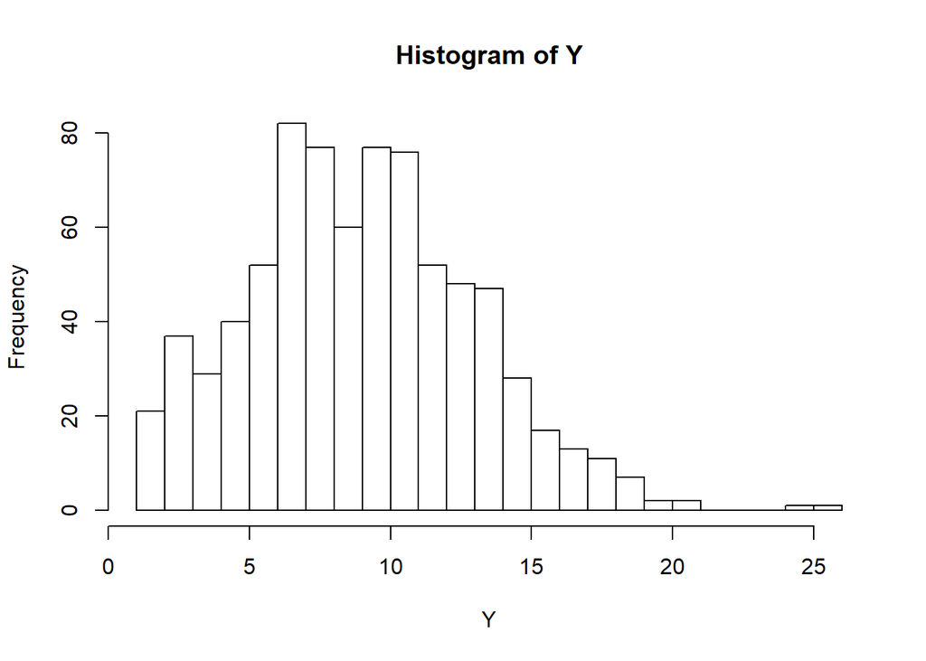

```r
#' Distribution of our response variable
hist(Y, breaks = 20)
```

Similar to the model for birth weight, I fit test models with different sets of priors for the NPB model. I went with the 5th set here, just like I did for the previous birth weight model.

```r
#' -----------------------------------------------------------------------------
#' Finding the NPB priors-- start with Lauren's from the example in the vignette
#'     Lauren's list of NPB priors (a list)
#' -----------------------------------------------------------------------------

set.seed(123)

#' Trying with default priors
priors.npb.1 <- list(alpha.pi = 1, beta.pi = 1, alpha.pi2 = 9, beta.pi2 = 1)

#' Run with standardized X and standardized W
fit.npb.1 <- npb(niter = 1000, nburn = 100, X = X.scaled, Y = Y, W = W.scaled,
                 scaleY = TRUE,
               priors = priors.npb.1, interact = TRUE)
npb.sum.1 <- summary(fit.npb.1)
npb.sum.1$main.effects
```

```
##       Posterior Mean         SD 95% CI Lower 95% CI Upper        PIP
##  [1,]   -0.009691327 0.03939045  -0.13792032   0.00000000 0.08555556
##  [2,]   -0.007683082 0.03452403  -0.12155167   0.00000000 0.07888889
##  [3,]   -0.008193744 0.03673399  -0.11704138   0.00000000 0.07777778
##  [4,]   -0.007554166 0.03363689  -0.12536468   0.00000000 0.07777778
##  [5,]   -0.002312689 0.02212689  -0.05583441   0.00000000 0.05222222
##  [6,]   -0.002615932 0.02369631  -0.06247033   0.00000000 0.04888889
##  [7,]   -0.001518220 0.02021844  -0.03429491   0.00000000 0.04000000
##  [8,]    0.003389633 0.03730292   0.00000000   0.00163443 0.04333333
##  [9,]   -0.002188634 0.01957950  -0.05081326   0.00000000 0.03666667
## [10,]   -0.005355908 0.02870253  -0.09604420   0.00000000 0.05666667
## [11,]   -0.012805298 0.05120545  -0.17956000   0.00000000 0.09888889
## [12,]   -0.011317779 0.04598079  -0.13802166   0.00000000 0.10000000
## [13,]   -0.018155700 0.06090919  -0.22392803   0.00000000 0.12111111
## [14,]   -0.008727024 0.03481982  -0.12548581   0.00000000 0.08666667
## [15,]   -0.028664631 0.08221112  -0.32190455   0.00000000 0.15888889
## [16,]   -0.006853389 0.03245378  -0.11146269   0.00000000 0.07000000
## [17,]   -0.012078592 0.05182664  -0.14410693   0.00000000 0.09000000
## [18,]   -0.002547123 0.02295198  -0.05630114   0.00000000 0.04777778
## [19,]   -0.017065655 0.06540388  -0.21988637   0.00000000 0.11111111
```

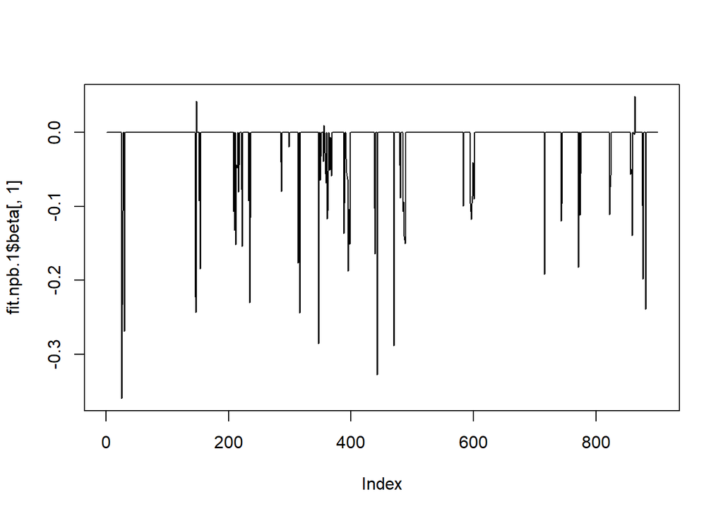

```r
plot(fit.npb.1$beta[,1], type = "l")
```

```r
#' Try making a.phi1 bigger
priors.npb.2 <- list(alpha.pi = 1, beta.pi = 1, alpha.pi2 = 9, beta.pi2 = 1,
                    a.phi1 = 10)

#' Run with standardized X and standardized W
fit.npb.2 <- npb(niter = 1000, nburn = 100, X = X.scaled, Y = Y, W = W.scaled,
                 scaleY = TRUE,
                 priors = priors.npb.2, interact = TRUE)
npb.sum.2 <- summary(fit.npb.2)
npb.sum.2$main.effects
```

```
##       Posterior Mean         SD 95% CI Lower 95% CI Upper        PIP
##  [1,]   -0.014487856 0.04579988  -0.17136154  0.000000000 0.15000000
##  [2,]   -0.010053043 0.03862081  -0.12946967  0.000000000 0.12222222
##  [3,]   -0.009774834 0.04125055  -0.14315486  0.000000000 0.12111111
##  [4,]   -0.011842957 0.04330767  -0.16372281  0.000000000 0.13555556
##  [5,]   -0.001277923 0.03360770  -0.07097374  0.009645752 0.09777778
##  [6,]   -0.003140567 0.03485078  -0.07858416  0.004969264 0.10888889
##  [7,]   -0.003477225 0.03450324  -0.07699292  0.000000000 0.09444444
##  [8,]    0.014323119 0.07330640  -0.03790602  0.278220320 0.11111111
##  [9,]   -0.001810766 0.03113498  -0.06621852  0.000000000 0.08555556
## [10,]   -0.008389866 0.03300626  -0.11764763  0.000000000 0.11555556
## [11,]   -0.015781753 0.04883716  -0.18274237  0.000000000 0.16333333
## [12,]   -0.013633013 0.05018792  -0.15930880  0.000000000 0.13888889
## [13,]   -0.025392214 0.07326946  -0.26566700  0.000000000 0.19333333
## [14,]   -0.006134869 0.03117071  -0.08868153  0.000000000 0.10222222
## [15,]   -0.048042558 0.10669945  -0.38641415  0.000000000 0.27111111
## [16,]   -0.011265915 0.04701143  -0.14737342  0.000000000 0.13777778
## [17,]   -0.014982793 0.05592305  -0.18110960  0.000000000 0.14111111
## [18,]   -0.001296954 0.03407189  -0.07179574  0.008531272 0.10333333
## [19,]   -0.025628552 0.07819997  -0.27875278  0.000000000 0.17555556
```

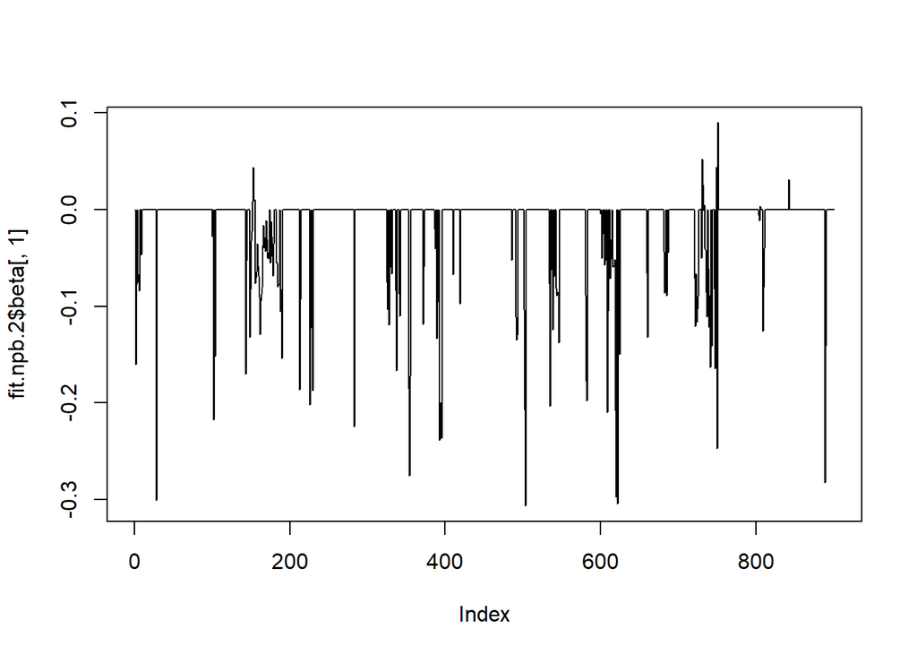

```r
plot(fit.npb.2$beta[,1], type = "l")
```

```r
#' Try making alpha.pi and beta.pi bigger
priors.npb.3 <- list(alpha.pi = 3, beta.pi = 3, alpha.pi2 = 9, beta.pi2 = 1,
                     a.phi1 = 50)

#' Run with standardized X and standardized W
fit.npb.3 <- npb(niter = 1000, nburn = 100, X = X.scaled, Y = Y, W = W.scaled,
                 scaleY = TRUE,
                 priors = priors.npb.3, interact = TRUE)
npb.sum.3 <- summary(fit.npb.3)
npb.sum.3$main.effects
```

```
##       Posterior Mean         SD 95% CI Lower 95% CI Upper       PIP
##  [1,]   -0.037766829 0.07471699  -0.24662764  0.000000000 0.3144444
##  [2,]   -0.023166269 0.05949421  -0.19850312  0.010397941 0.2455556
##  [3,]   -0.019698425 0.06171508  -0.20946058  0.011669199 0.2155556
##  [4,]   -0.026725433 0.06853668  -0.21371420  0.000000000 0.2488889
##  [5,]    0.002040777 0.05319407  -0.09791056  0.133807678 0.1711111
##  [6,]   -0.006553214 0.04635300  -0.13802805  0.070833512 0.1800000
##  [7,]   -0.002008731 0.04984242  -0.11967808  0.128557677 0.1522222
##  [8,]    0.031500156 0.10706621  -0.06965779  0.396248159 0.2188889
##  [9,]    0.002883456 0.05704369  -0.09493322  0.159911916 0.1666667
## [10,]   -0.020238925 0.05706981  -0.19308643  0.008493508 0.2255556
## [11,]   -0.044018667 0.08692131  -0.29551968  0.000000000 0.3255556
## [12,]   -0.030386795 0.08225621  -0.27803882  0.050267573 0.2822222
## [13,]   -0.044806677 0.08912268  -0.29781219  0.000000000 0.3311111
## [14,]   -0.006148289 0.06178203  -0.14226974  0.134415374 0.2122222
## [15,]   -0.101560542 0.13187686  -0.42522150  0.000000000 0.5288889
## [16,]   -0.026564897 0.06910708  -0.24572741  0.010784723 0.2544444
## [17,]   -0.050657569 0.09845361  -0.34056273  0.000000000 0.3266667
## [18,]    0.011495796 0.09235659  -0.11278227  0.329829037 0.2222222
## [19,]   -0.053927520 0.11057196  -0.39030389  0.000000000 0.3300000
```

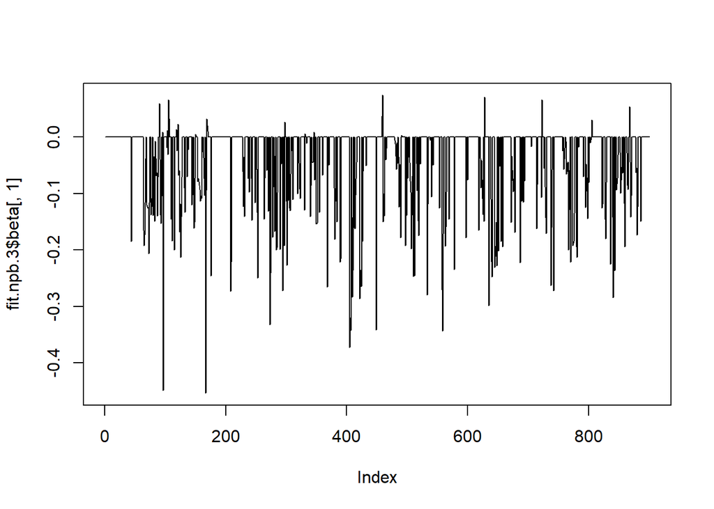

```r
plot(fit.npb.3$beta[,1], type = "l")
```

```r
#' Try making a.phi1 much, much bigger
priors.npb.4 <- list(alpha.pi = 3, beta.pi = 3, alpha.pi2 = 9, beta.pi2 = 1,
                     a.phi1 = 100)

#' Run with standardized X and standardized W
fit.npb.4 <- npb(niter = 1000, nburn = 100, X = X.scaled, Y = Y, W = W.scaled,
                 scaleY = TRUE,
                 priors = priors.npb.4, interact = TRUE)
npb.sum.4 <- summary(fit.npb.4)
npb.sum.4$main.effects
```

```
##       Posterior Mean         SD 95% CI Lower 95% CI Upper       PIP
##  [1,]  -0.0448791666 0.07795142   -0.2439698 0.0043704604 0.3800000
##  [2,]  -0.0298746311 0.06703614   -0.2173700 0.0052234278 0.2911111
##  [3,]  -0.0253329315 0.06375710   -0.1988895 0.0256743633 0.2944444
##  [4,]  -0.0299942920 0.07550136   -0.2514679 0.0237953154 0.3000000
##  [5,]  -0.0006804903 0.05503912   -0.1265154 0.1335937529 0.2055556
##  [6,]  -0.0104707334 0.05333098   -0.1541096 0.0766585640 0.2344444
##  [7,]  -0.0061191109 0.05788793   -0.1481107 0.1094418676 0.2300000
##  [8,]   0.0416506194 0.11906863   -0.0806320 0.4252849671 0.2788889
##  [9,]   0.0034713867 0.06079789   -0.1165193 0.1988471163 0.2400000
## [10,]  -0.0204689527 0.06335631   -0.1963805 0.0544382144 0.2700000
## [11,]  -0.0517782447 0.09008890   -0.3141432 0.0172818790 0.4155556
## [12,]  -0.0305366170 0.07243324   -0.2368970 0.0308254376 0.3155556
## [13,]  -0.0483951832 0.08912109   -0.3050162 0.0216236153 0.3911111
## [14,]  -0.0135516120 0.05342735   -0.1504376 0.0761672826 0.2533333
## [15,]  -0.1115980658 0.12617104   -0.4051227 0.0000000000 0.6077778
## [16,]  -0.0310132656 0.07582448   -0.2492303 0.0626577451 0.3288889
## [17,]  -0.0502858216 0.09361329   -0.3208663 0.0007889728 0.3866667
## [18,]   0.0051979652 0.08474241   -0.1337593 0.2494606802 0.2522222
## [19,]  -0.0538016568 0.09984699   -0.3212564 0.0010712002 0.3944444
```

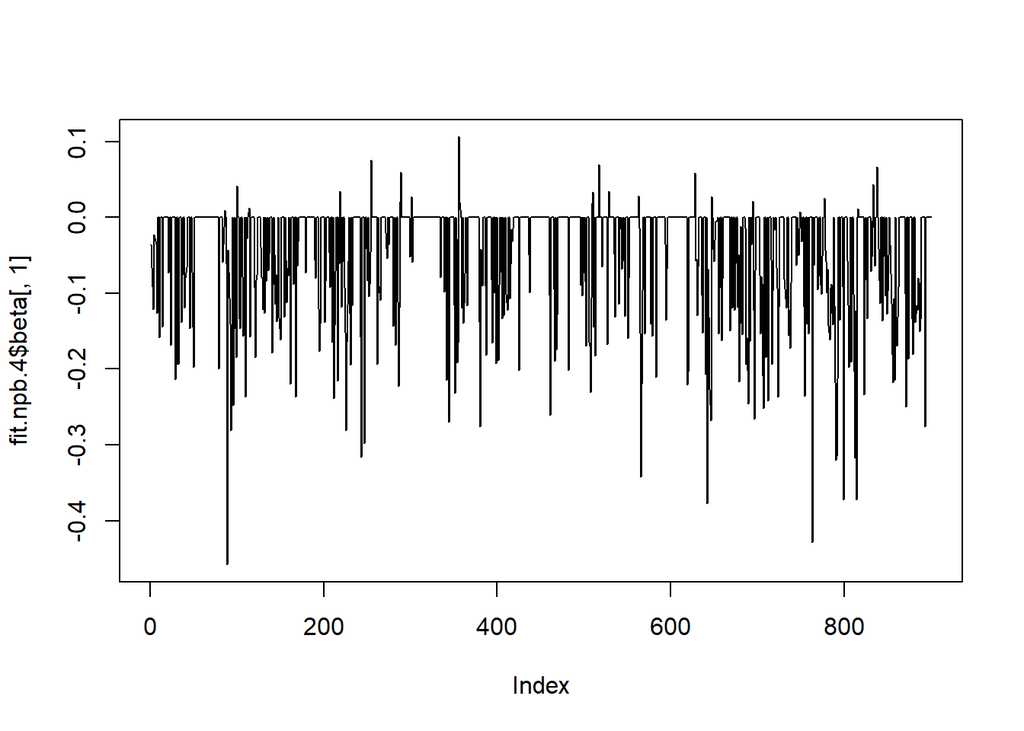

```r
plot(fit.npb.4$beta[,1], type = "l")
```

```r
#' Try increasing alpha.pi and beta.pi one more time
priors.npb.5 <- list(alpha.pi = 10, beta.pi = 10, alpha.pi2 = 9, beta.pi2 = 1,
                     a.phi1 = 100)

#' Run with standardized X and standardized W
fit.npb.5 <- npb(niter = 1000, nburn = 100, X = X.scaled, Y = Y, W = W.scaled,
                 scaleY = TRUE,
                 priors = priors.npb.5, interact = TRUE)
npb.sum.5 <- summary(fit.npb.5)
npb.sum.5$main.effects
```

```
##       Posterior Mean         SD 95% CI Lower 95% CI Upper       PIP
##  [1,]   -0.053939928 0.08226195  -0.25688098  0.009620465 0.4700000
##  [2,]   -0.037766481 0.07330488  -0.23931379  0.024668779 0.3866667
##  [3,]   -0.033593174 0.07138941  -0.22673045  0.070759642 0.4055556
##  [4,]   -0.040547926 0.07883560  -0.24018345  0.055959186 0.4111111
##  [5,]    0.008817410 0.06916414  -0.10708490  0.233713477 0.2733333
##  [6,]   -0.011886253 0.06728839  -0.17764231  0.157638763 0.3244444
##  [7,]   -0.001726916 0.07592666  -0.15686095  0.211163831 0.3033333
##  [8,]    0.049845497 0.12391595  -0.09371596  0.409033227 0.3544444
##  [9,]    0.013653581 0.08125011  -0.10460693  0.270825199 0.3188889
## [10,]   -0.025414301 0.06976860  -0.19687904  0.075143634 0.3455556
## [11,]   -0.069330310 0.10271075  -0.30718159  0.035712510 0.5255556
## [12,]   -0.032322785 0.08199069  -0.23292999  0.087329172 0.4166667
## [13,]   -0.064137009 0.09975403  -0.32843734  0.027176818 0.5055556
## [14,]   -0.011276938 0.07456849  -0.16985027  0.169395096 0.3733333
## [15,]   -0.123690654 0.12423042  -0.42203835  0.000000000 0.7111111
## [16,]   -0.030097101 0.07753503  -0.22274064  0.105085350 0.3877778
## [17,]   -0.068608750 0.10609141  -0.34225607  0.007998315 0.4988889
## [18,]    0.013546806 0.08895650  -0.12399316  0.286175357 0.3022222
## [19,]   -0.067620473 0.10772674  -0.33935379  0.016595780 0.5088889
```

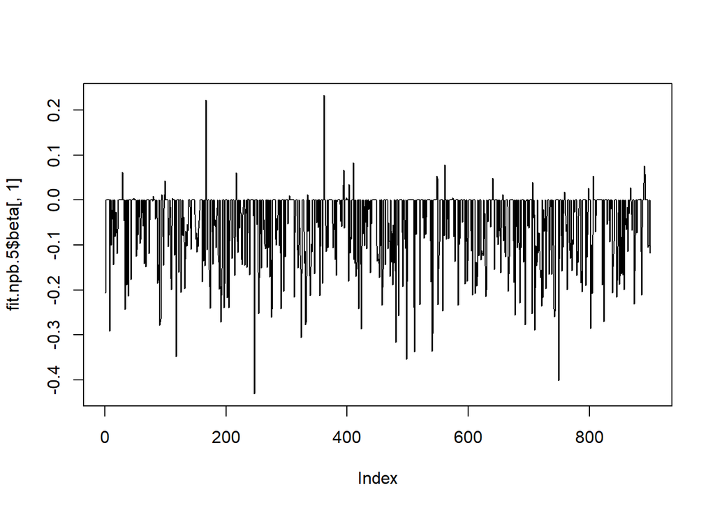

```r
plot(fit.npb.5$beta[,1], type = "l")
```

After picking the priors, I fit the NPB model using 10,000 iterations.

```r
#' -----------------------------------------------------------------------------
#' Fitting the nonparametric Bayesian shrinkage model:
#' Going to go with the fifth set of priors as described above
#' Because this is a screening model, going to set PIP criterion to 0.40
#' -----------------------------------------------------------------------------

priors.npb <- priors.npb.5

# fit.npb <- npb(niter = 10000, nburn = 1000, X = X.scaled, Y = Y, W = W.scaled,
#                scaleY = TRUE,
#                priors = priors.npb, interact = TRUE)
load(here::here("Results", "NPB_Models_AD.rdata"))
npb.sum <- summary(fit.npb)

#' First, main effect regression coefficients with PIP
#' 10 variables had PIPs above 0.40
npb.sum$main.effects
```

```
##       Posterior Mean         SD 95% CI Lower 95% CI Upper       PIP
##  [1,]   -0.055574370 0.08756286  -0.27799946   0.03579725 0.4860000
##  [2,]   -0.038756259 0.07495976  -0.23509999   0.04525794 0.4083333
##  [3,]   -0.031691313 0.07297671  -0.23273337   0.06568175 0.3805556
##  [4,]   -0.035962447 0.07676540  -0.23484558   0.05613941 0.4034444
##  [5,]    0.007936920 0.07290585  -0.11864545   0.23515879 0.2988889
##  [6,]   -0.010001387 0.06665436  -0.17597590   0.14514136 0.3140000
##  [7,]   -0.004679302 0.06711060  -0.15943134   0.16721605 0.2977778
##  [8,]    0.048506091 0.12241131  -0.09284542   0.40860145 0.3657778
##  [9,]    0.007525080 0.07468890  -0.12804994   0.23273300 0.2944444
## [10,]   -0.027660987 0.07263105  -0.22219366   0.07580181 0.3603333
## [11,]   -0.068622237 0.10111827  -0.32562479   0.02822606 0.5298889
## [12,]   -0.037165295 0.08531325  -0.25408183   0.08391971 0.4186667
## [13,]   -0.061582498 0.09914144  -0.31913434   0.03368318 0.5048889
## [14,]   -0.013650771 0.07446637  -0.17913079   0.16108324 0.3521111
## [15,]   -0.121657046 0.12832564  -0.42966357   0.00000000 0.6972222
## [16,]   -0.033390473 0.08227186  -0.24675270   0.09415122 0.4014444
## [17,]   -0.061370990 0.09939396  -0.32739449   0.02576973 0.4842222
## [18,]    0.017464105 0.10271099  -0.13031208   0.33497230 0.3428889
## [19,]   -0.067349255 0.11362432  -0.37381716   0.02850520 0.4905556
```

```r
selected_exp <- c(1,2,4,11,12,13,15,16,17,19)

#' Which variables are these?
exp_names <- colnames(X)[selected_exp]
exp_names
```

```
##  [1] "mean_pm"             "mean_o3"             "pct_impervious"
##  [4] "dist_m_mine_well"    "cvd_rate_adj"        "res_rate_adj"
##  [7] "property_crime_rate" "pct_less_hs"         "pct_unemp"
## [10] "pct_hh_pov"
```

```r
#' Next, all of the interactions
#' No interactions showed up here
npb.sum$interactions
```

```
##          Posterior Mean          SD 95% CI Lower 95% CI Upper          PIP
##   [1,]  0.0005152124401 0.010287294            0            0 0.0044444444
##   [2,] -0.0000022585079 0.004244815            0            0 0.0020000000
##   [3,] -0.0004464051049 0.010554963            0            0 0.0043333333
##   [4,]  0.0000519516056 0.003901716            0            0 0.0016666667
##   [5,] -0.0000131767477 0.004453971            0            0 0.0020000000
##   [6,] -0.0000762801570 0.004841327            0            0 0.0017777778
##   [7,] -0.0006403613645 0.014114642            0            0 0.0035555556
##   [8,] -0.0003645324789 0.009829006            0            0 0.0031111111
##   [9,] -0.0000583070234 0.006590334            0            0 0.0020000000
##  [10,] -0.0001370545488 0.005140435            0            0 0.0017777778
##  [11,] -0.0001079902127 0.004770665            0            0 0.0014444444
##  [12,]  0.0000263309410 0.003592878            0            0 0.0017777778
##  [13,] -0.0000732192212 0.004159043            0            0 0.0021111111
##  [14,]  0.0001165559273 0.003791336            0            0 0.0024444444
```

[output cut: 157 more lines]

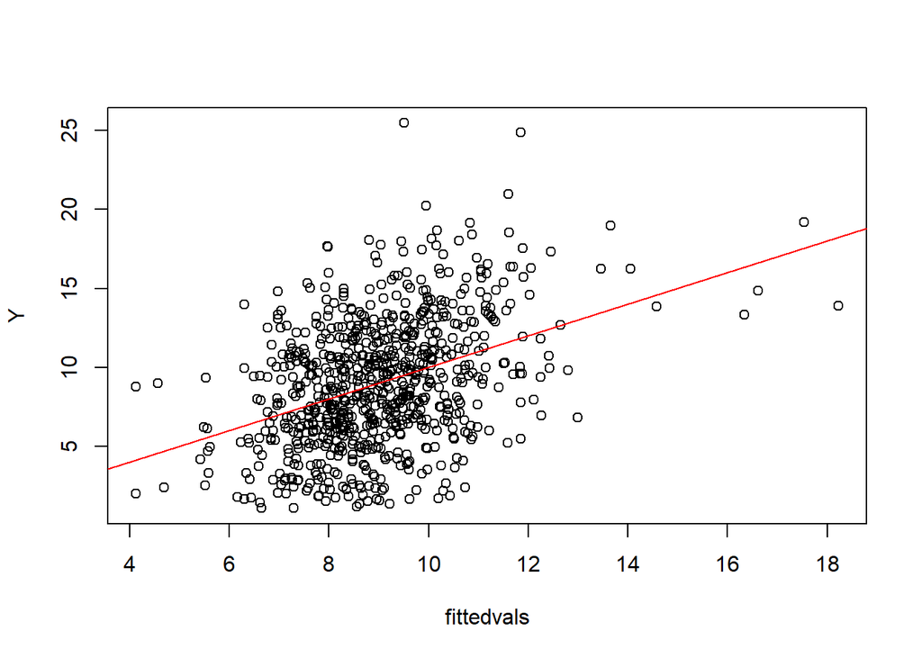

```r
#' Predict fitted values for each individual
pred.npb <- predict(fit.npb)
fittedvals <- pred.npb$fitted.vals

#' Plot predicted outcomes against "measured" outcomes
plot(fittedvals, Y)
abline(a = 0, b = 1, col = "red")
```

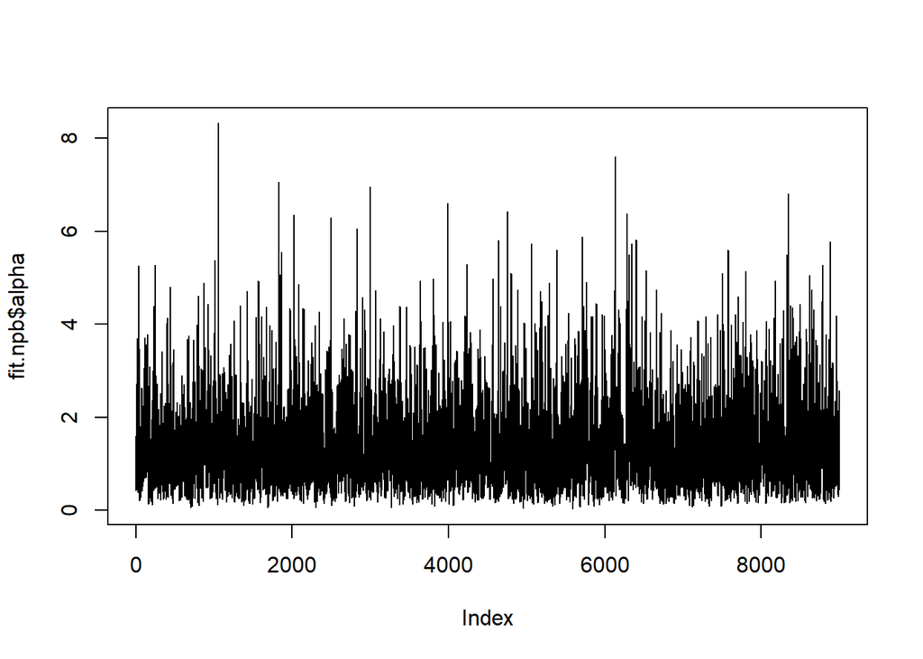

```r
#' Trace plots for the iterations
plot(fit.npb$alpha, type = "l")
```

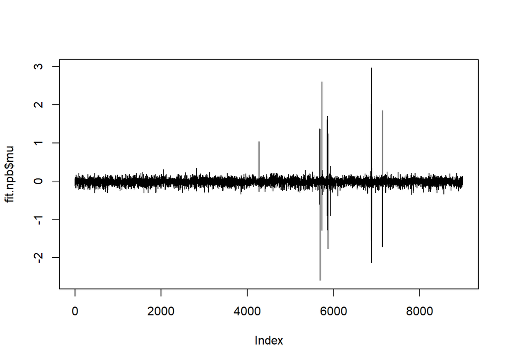

```r
plot(fit.npb$mu, type = "l")
```

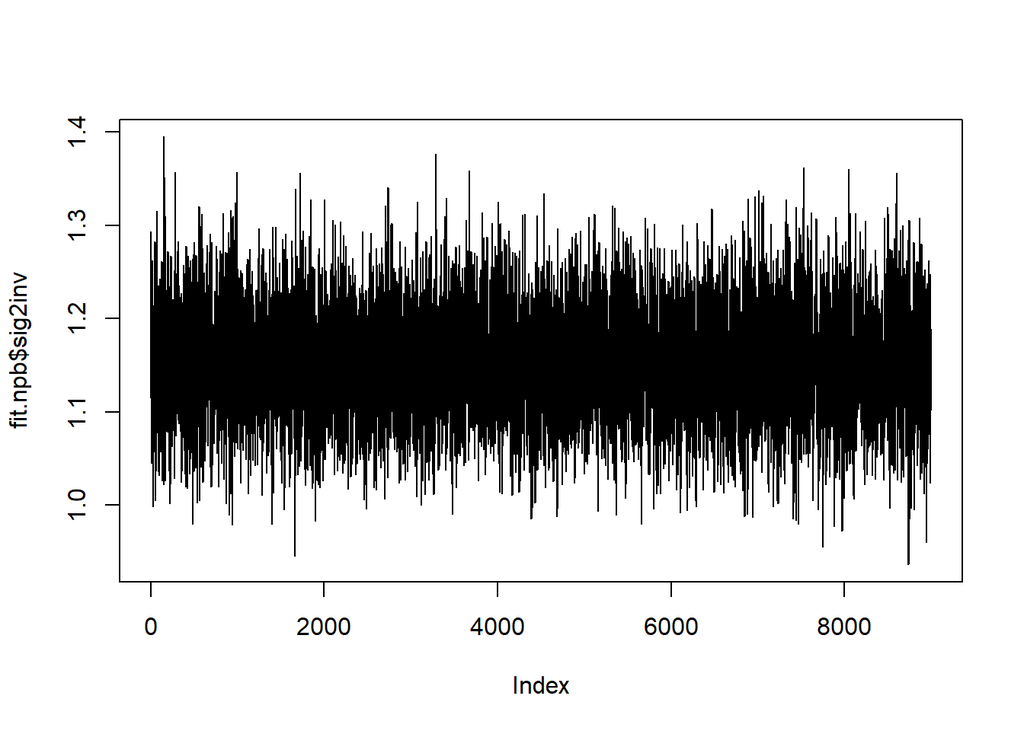

```r
plot(fit.npb$sig2inv, type = "l")
```

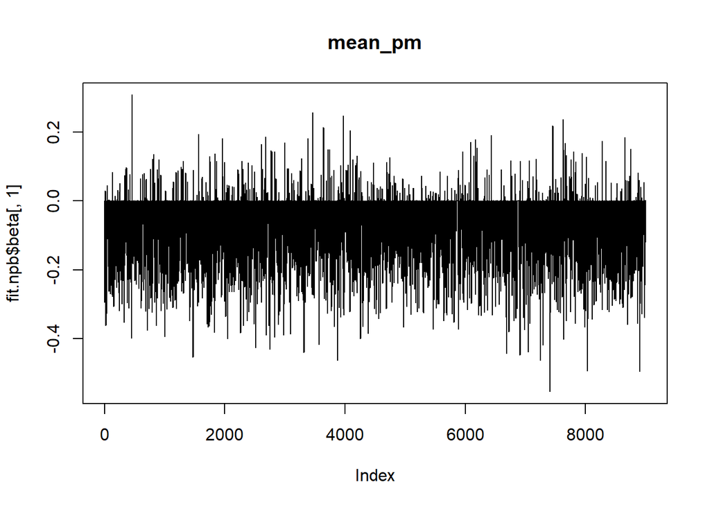

```r
plot(fit.npb$beta[,1], type = "l", main = colnames(X)[1])
```

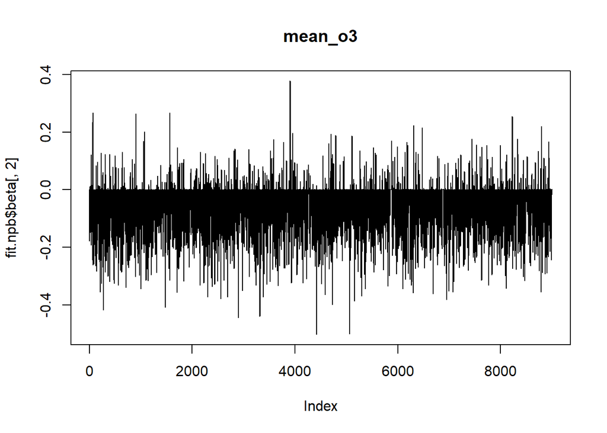

```r
plot(fit.npb$beta[,2], type = "l", main = colnames(X)[2])
```

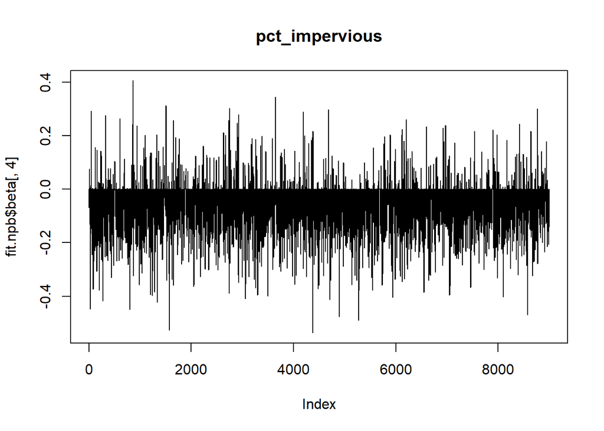

```r
plot(fit.npb$beta[,4], type = "l", main = colnames(X)[4])
```

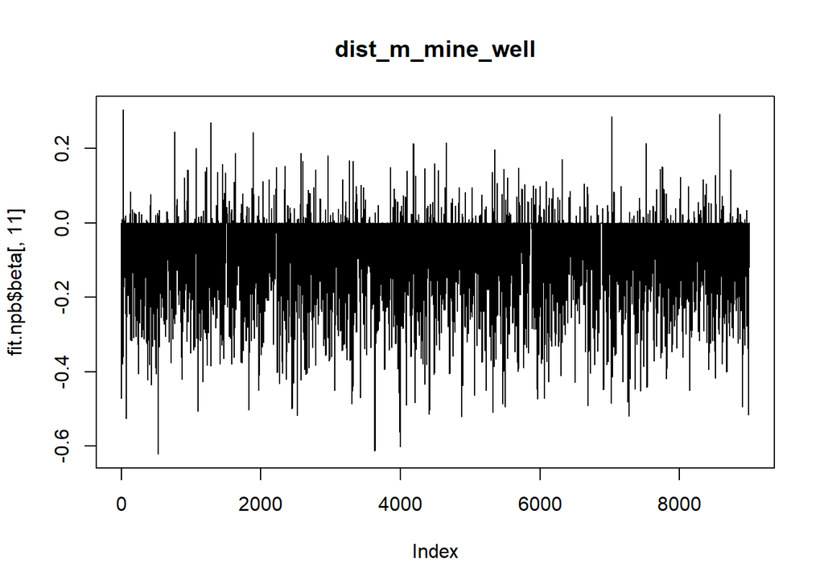

```r
plot(fit.npb$beta[,11], type = "l", main = colnames(X)[11])
```

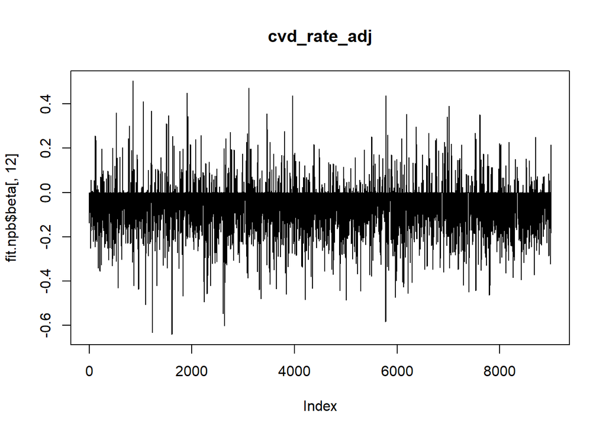

```r
plot(fit.npb$beta[,12], type = "l", main = colnames(X)[12])
```

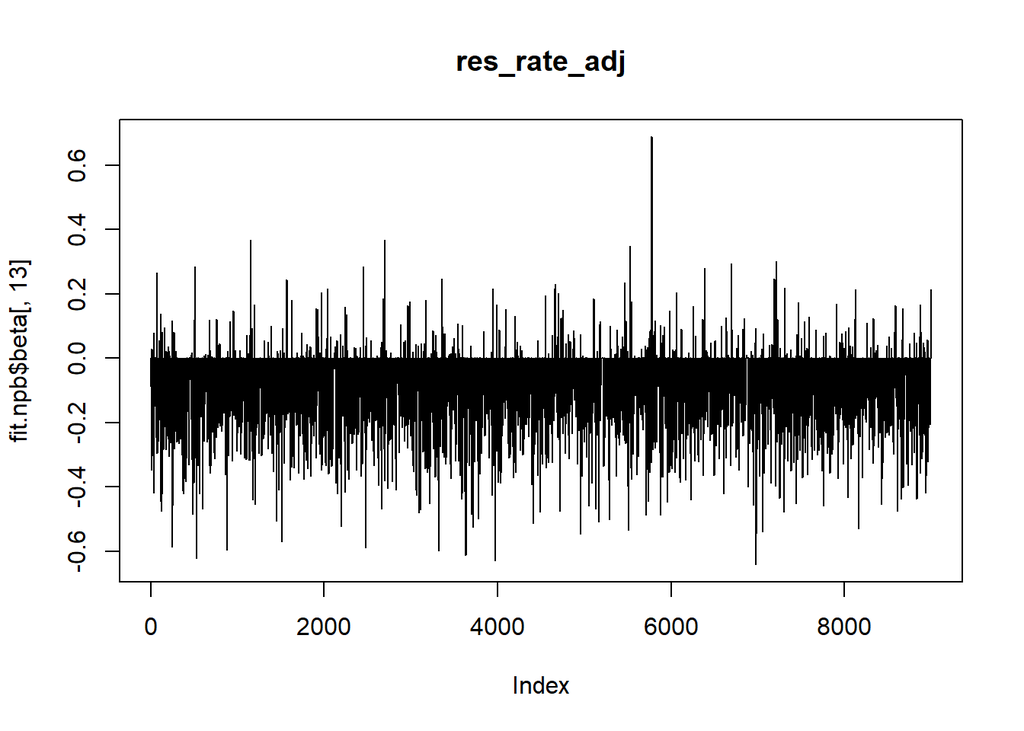

```r
plot(fit.npb$beta[,13], type = "l", main = colnames(X)[13])
```

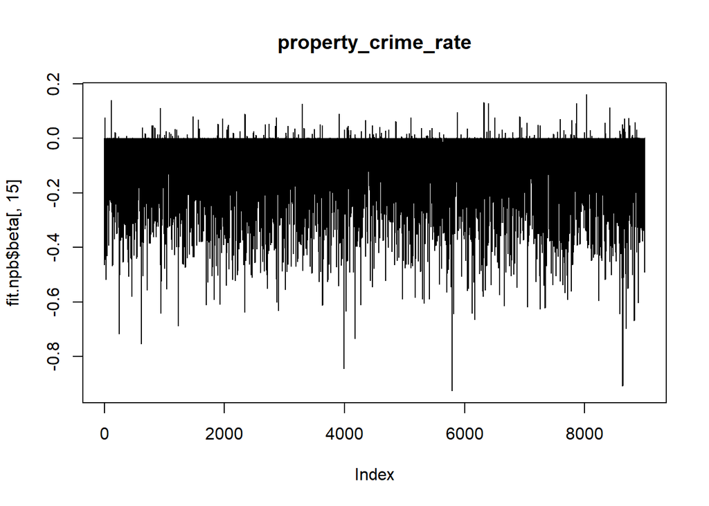

```r
plot(fit.npb$beta[,15], type = "l", main = colnames(X)[15])
```

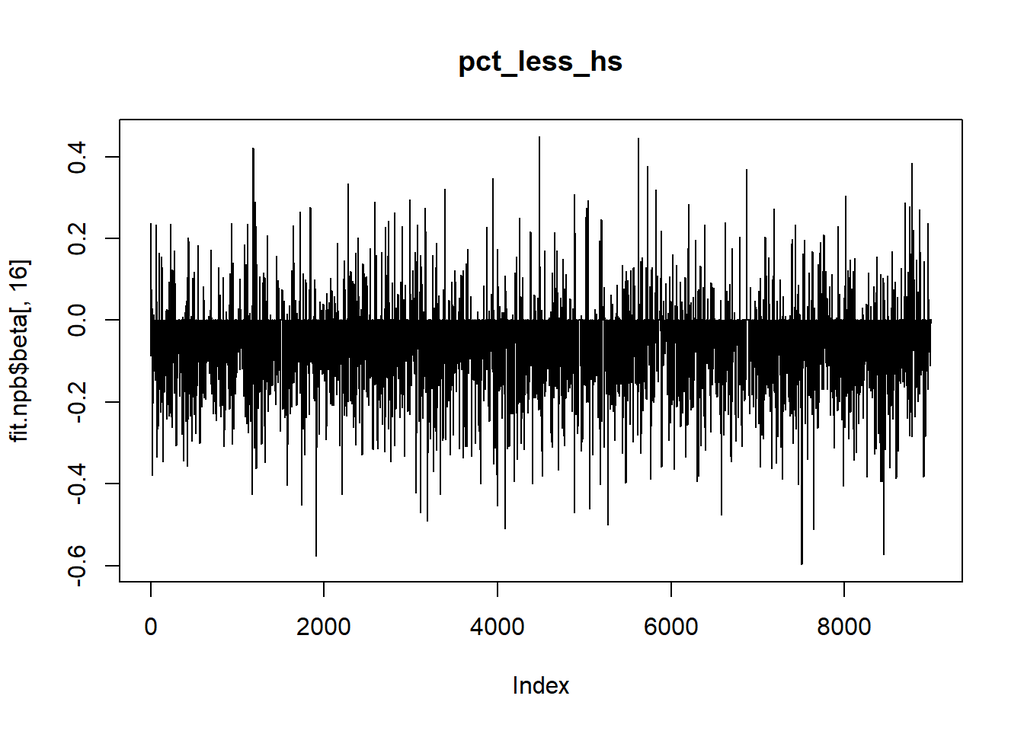

```r
plot(fit.npb$beta[,16], type = "l", main = colnames(X)[16])
```

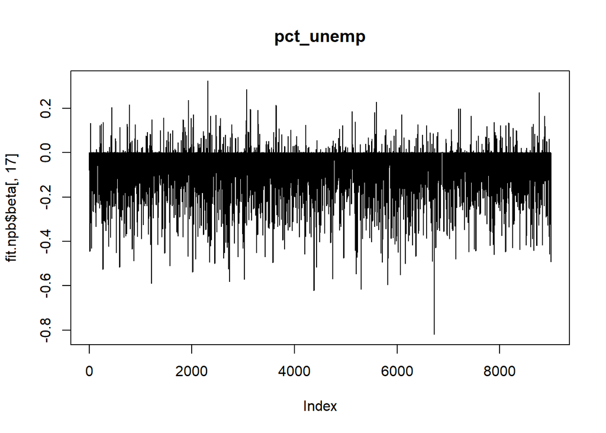

```r
plot(fit.npb$beta[,17], type = "l", main = colnames(X)[17])
```

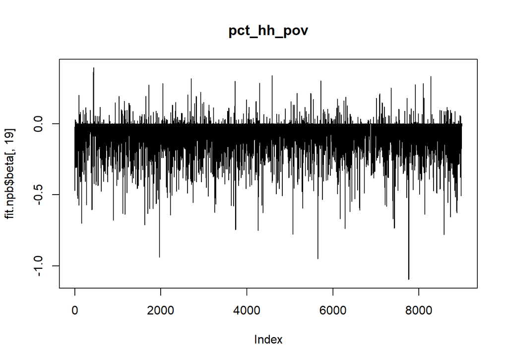

```r
plot(fit.npb$beta[,19], type = "l", main = colnames(X)[19])
```

```r
# save(priors.npb, fit.npb, npb.sum, exp_names,
#      file = here::here("Results", "NPB_Models_AD.rdata"))
```